# Szeregi czasowe - Projekt zaliczeniowy

Paweł Strzępka

2023-06-13

# **Analizowane dane**

Dane pobrane zostały ze strony https://fred.stlouisfed.org.

Dane (z widoczną sezonowością) dotyczące indeksu cen producentów w branży hotelarskiej (Hotels and Motels, Except Casino Hotels) odnoszą się do zmian cen usług hotelarskich z wyłączeniem hoteli kasynowych. Zagadnienie indeksu cen producentów w branży hotelarskiej dostarcza kluczowych informacji dotyczących zmian cen w sektorze hotelarskim, inflacji, planowania finansowego, konkurencyjności oraz prognozowania popytu i podaży. Pomiary wykonane zostały co miesiąc od 01.12.2003 do 01.04.2023.

Dane (z widocznym trendem) dotyczące zaawansowanych sprzedaży detalicznych w handlu detalicznym (Advance Retail Sales: Retail Trade) są istotnym wskaźnikiem ekonomicznym, który odzwierciedla zmiany sprzedaży detalicznej w sektorze handlu. Dane dotyczące handlu detalicznego dostarczają kluczowych informacji na temat kondycji gospodarki, trendów konsumpcyjnych i efektywności strategii biznesowych. Trafne prognozy w tej dziedzinie mogą przynieść korzyści dla przedsiębiorców oraz inwestorów. Pomiary wykonane zostały co miesiąc od 01.01.1992 do 01.04.2023.

```r
library(readxl)
library(lubridate)
library(forecast)
library(expsmooth)
library(fma)
```

```r
getwd()
```

```
## [1] "D:/materialystudia/ProjektSzeregi"
```

```r
setwd('D:/materialystudia/ProjektSzeregi')

dane1 <- read.csv("PCU721110721110.csv", header=T, sep=",")

dane2 <- read.csv("RSXFS.csv", header=T, sep=",")
```

```r
szereg1 <- ts(dane1$PCU721110721110, start=decimal_date(ymd("2003-12-01")), freq = 12)
is.ts(szereg1)
```

```
## [1] TRUE
```

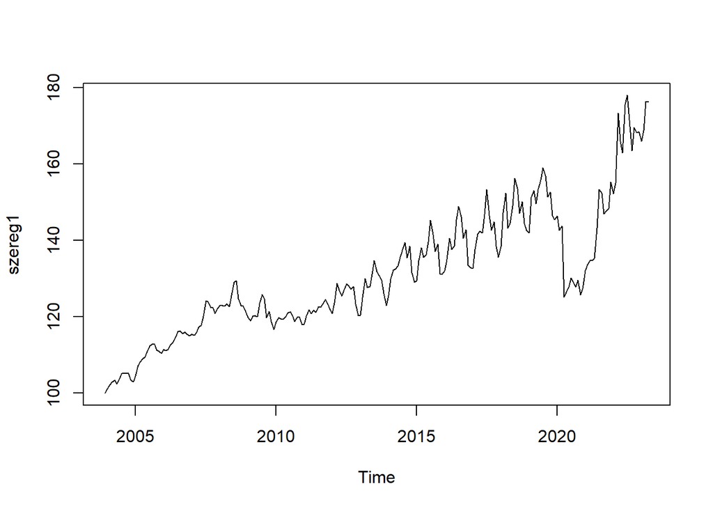

```r
plot(szereg1)
```

Duży spadek w 2020 roku spowodowany przez pandemię covid-19

```r
szereg2 <- ts(dane2$RSXFS, start=decimal_date(ymd("1992-01-01")), freq = 12)
is.ts(szereg2)
```

```
## [1] TRUE
```

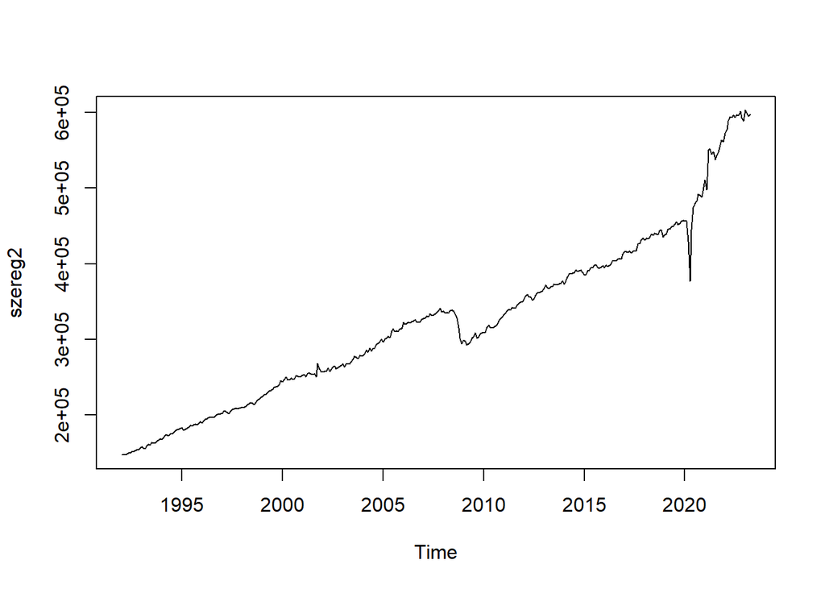

```r
plot(szereg2)
```

Spadek w 2008 roku może byc spowodowany ogólnoświatowym kryzysem gospodarczym w latach 2007-2009

# **Omówienie głównych cech analizowanych szeregów na podstawie wykresów**

## Szereg z wyraźną sezonowością

### Wykres sezonowy monthplot()

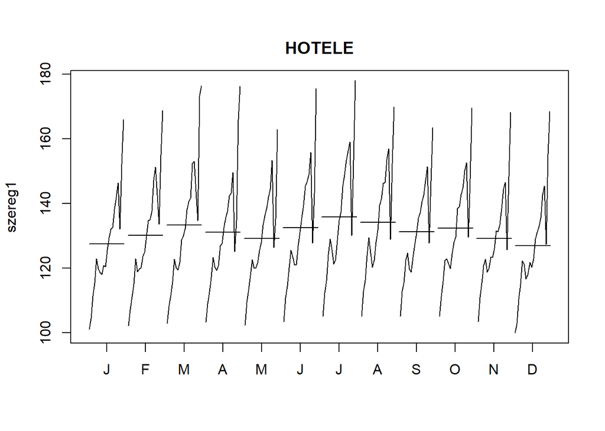

```r
monthplot(szereg1)
title(main = "HOTELE", line = 1)
```

### Wykresy pudełkowe boxplot()

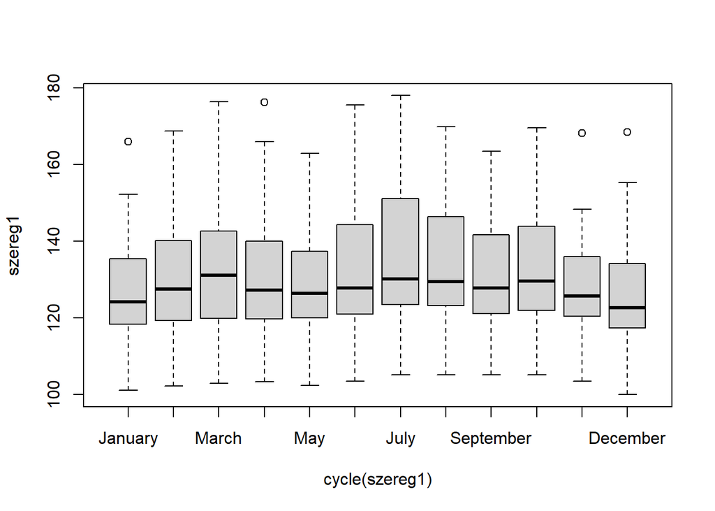

```r
boxplot(szereg1 ~ cycle(szereg1), names=month.name)
```

Możemy zaobserwoować wartości znacznie odstające od reszty. Na wykresie mamy mediany, kwartyle, wartości minimalne i maksymalne oraz wartości odstające.

### Wykres sezonowy seasonplot()

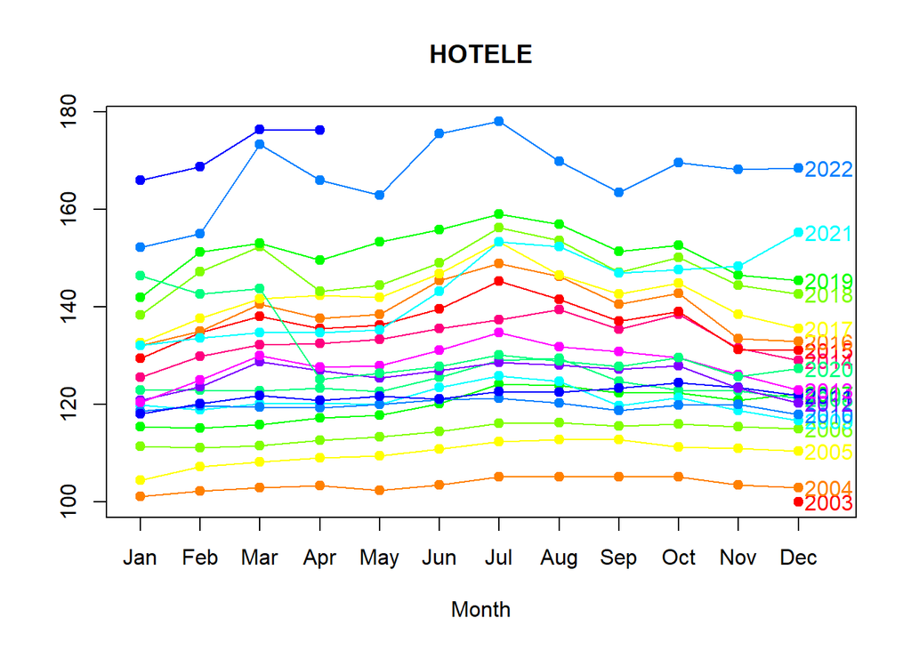

```r
seasonplot(szereg1, col = rainbow(12), main = "HOTELE",  year.labels = TRUE, pch=19, lwd=1.0)
```

Możemy zaobserwować sezonowość i trend rosnący

### Wykresy rozrzutu dla wartości opóźnionych lag.plot()

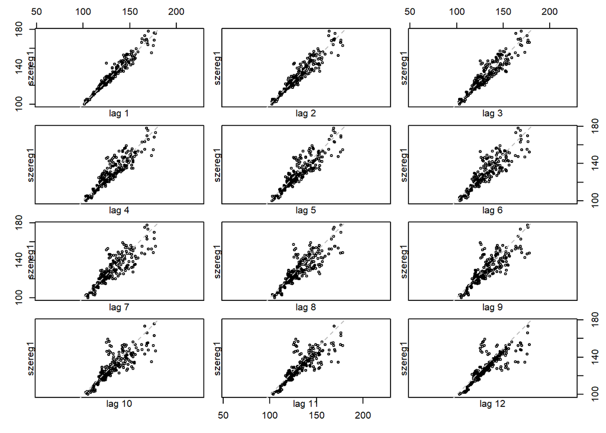

```r
lag.plot(szereg1, lags=12)
```

Istotna zależność dla opóźnienia równego 1 sugeruje obecność trendu. Silna zależność występująca dla opóźnienia 12 sugeruje sezonowość roczną.

### Wykres autokorelacji Acf

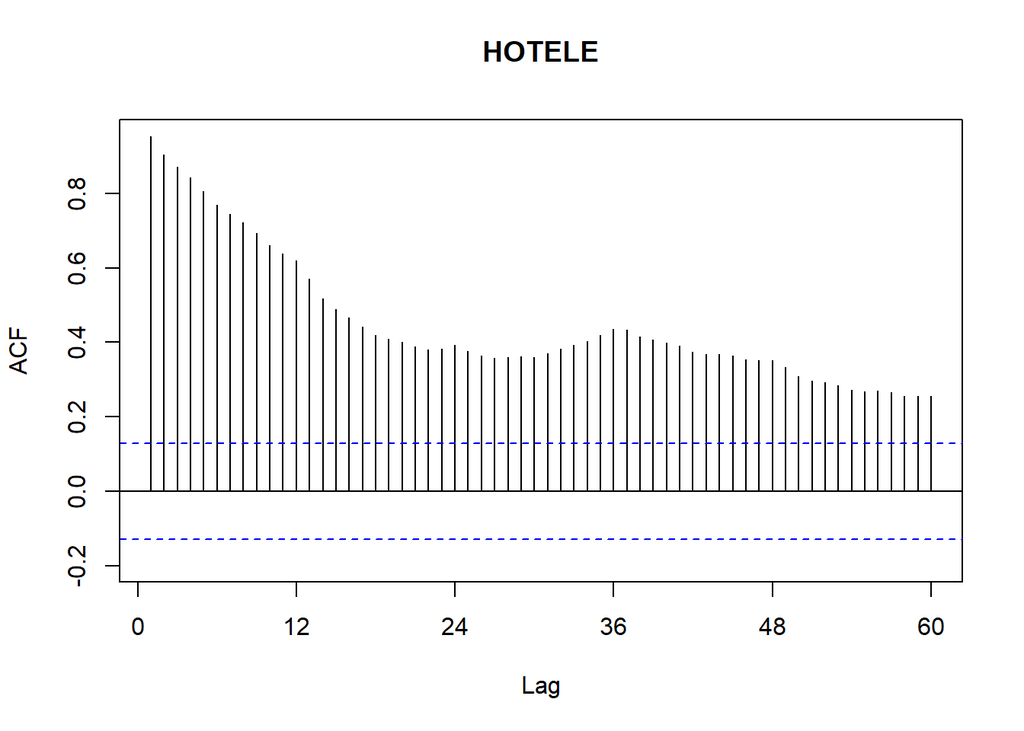

```r
Acf(szereg1, lag.max = 60, main = "HOTELE")
```

Wartości ACF zanikające powoli i cyklicznie sugerują obecność sezonowości

### Wykres cząstkowej autokorelacji Pacf

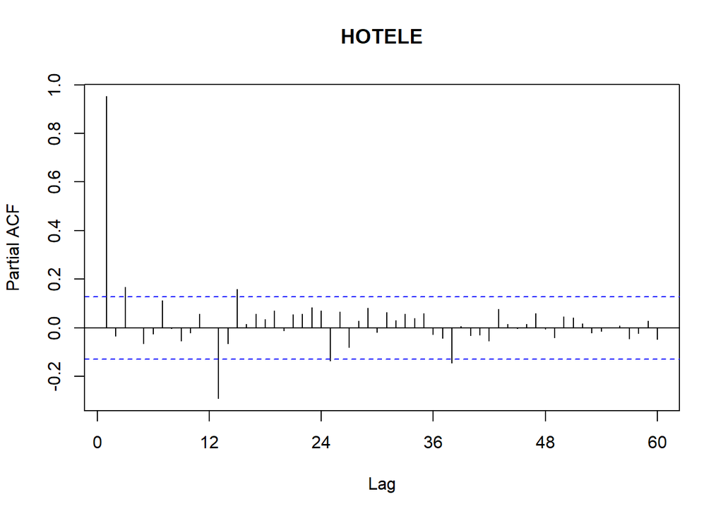

```r
Pacf(szereg1, lag.max = 60, main = "HOTELE")
```

Wartość dla opóźnienia lag=1 świadczy zwykle o obecności trendu wzrostowego

## Szereg z wyraźnym trendem

### Wykres sezonowy monthplot()

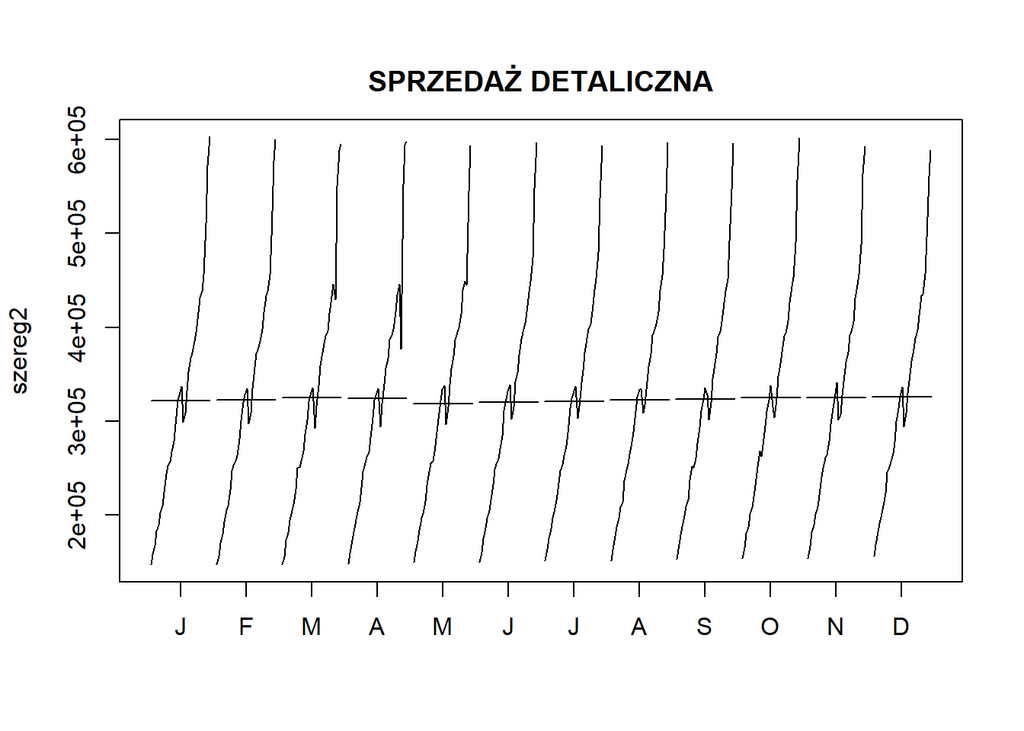

```r
monthplot(szereg2)
title(main = "SPRZEDAŻ DETALICZNA", line = 1)
```

### Wykresy pudełkowe boxplot()

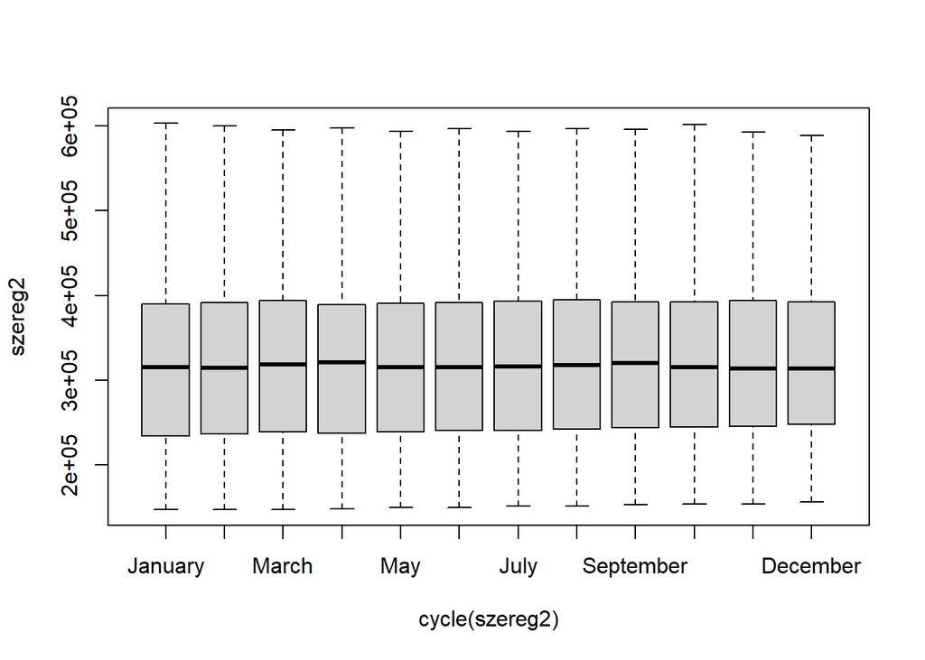

```r
boxplot(szereg2 ~ cycle(szereg2), names=month.name)
```

Brak wartości znacznie odstających od reszty. Na wykresie mamy mediany, kwartyle, wartości minimalne i maksymalne oraz wartości odstające.

### Wykres sezonowy seasonplot()

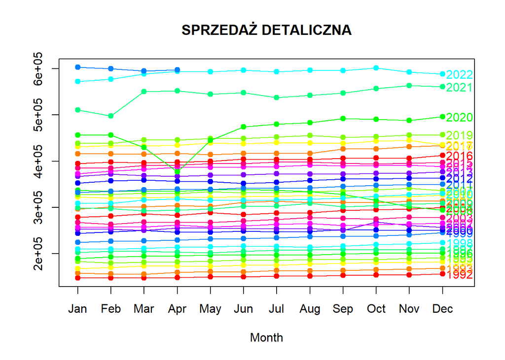

```r
seasonplot(szereg2, col = rainbow(12), main = "SPRZEDAŻ DETALICZNA", year.labels = TRUE, pch=19, lwd=1.0)
```

Możemy zaobserwować wystepujący trend rosnący

### Wykresy rozrzutu dla wartości opóźnionych lag.plot()

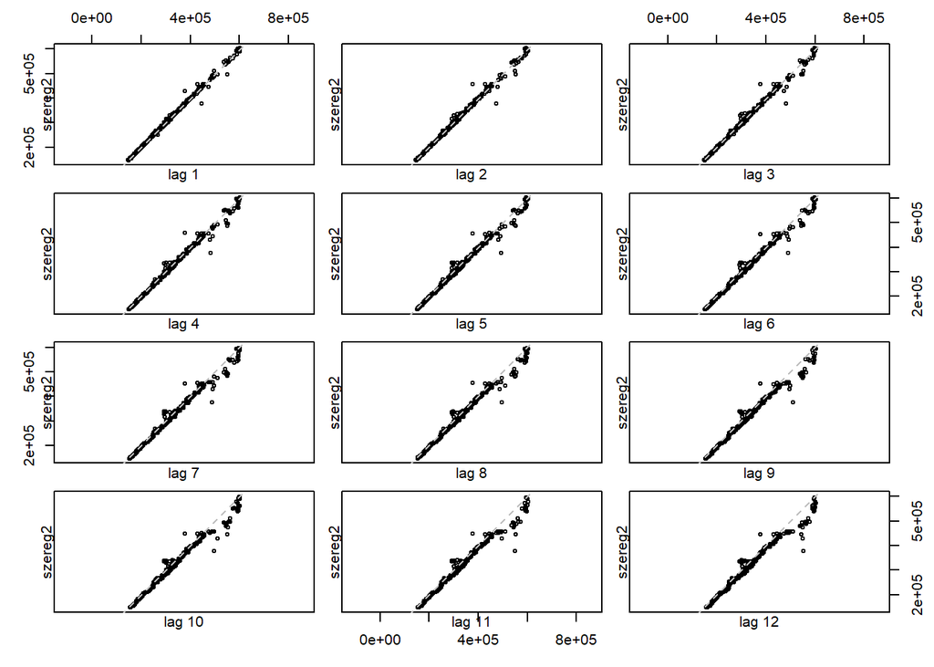

```r
lag.plot(szereg2, lags=12)
```

Największa korelacja występuje dla lag=1 co może oznaczać trend rosnący

### Wykres autokorelacji Acf

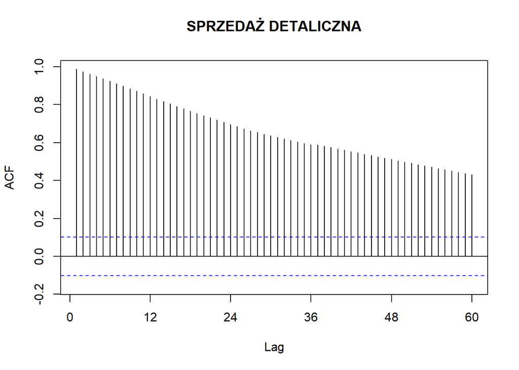

```r
Acf(szereg2, lag.max = 60,  main = "SPRZEDAŻ DETALICZNA")
```

Dodatnie i powoli zanikające wartości funkcji ACF sugerują, że dane zawierają deterministyczną składową trendu

### Wykres cząstkowej autokorelacji Pacf

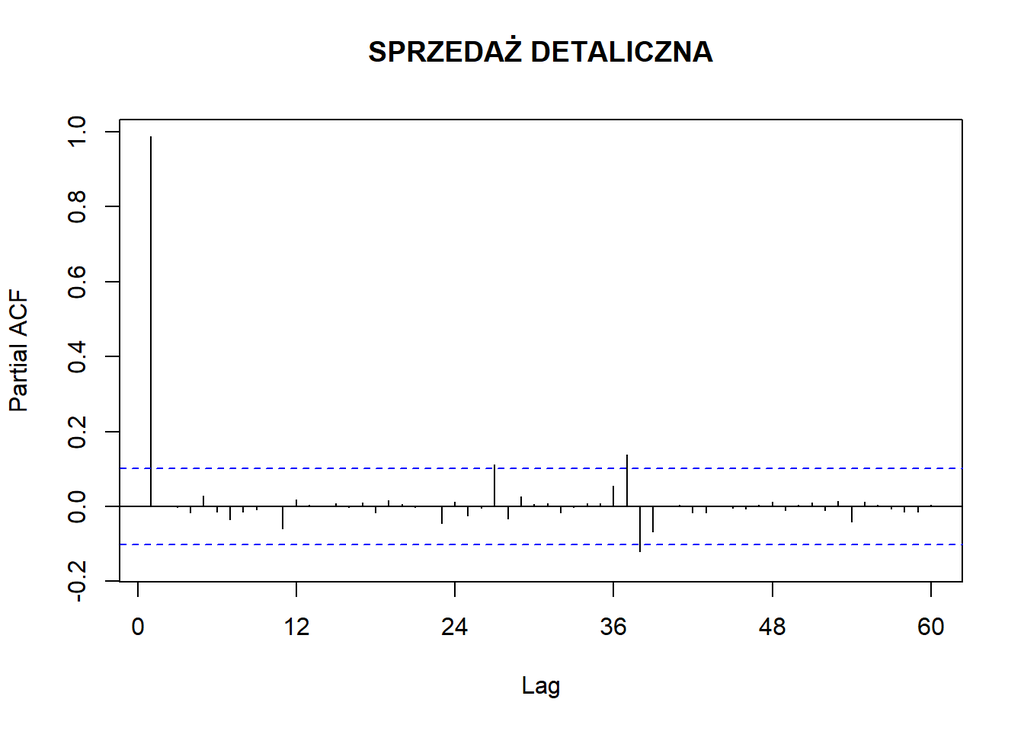

```r
Pacf(szereg2, lag.max = 60,  main = "SPRZEDAŻ DETALICZNA")
```

Duża wartość dla opóźnienia lag=1 świadczy o obecności silnego trendu wzrostowego

# **Dekompozycja**

## Szereg z wyraźną sezonowością

### Dekompozycja addytywna

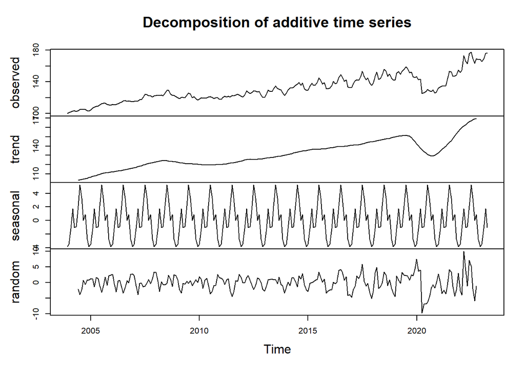

```r
plot(decompose(szereg1, type="additive"))
```

### Dekompozycja multiplikatywna

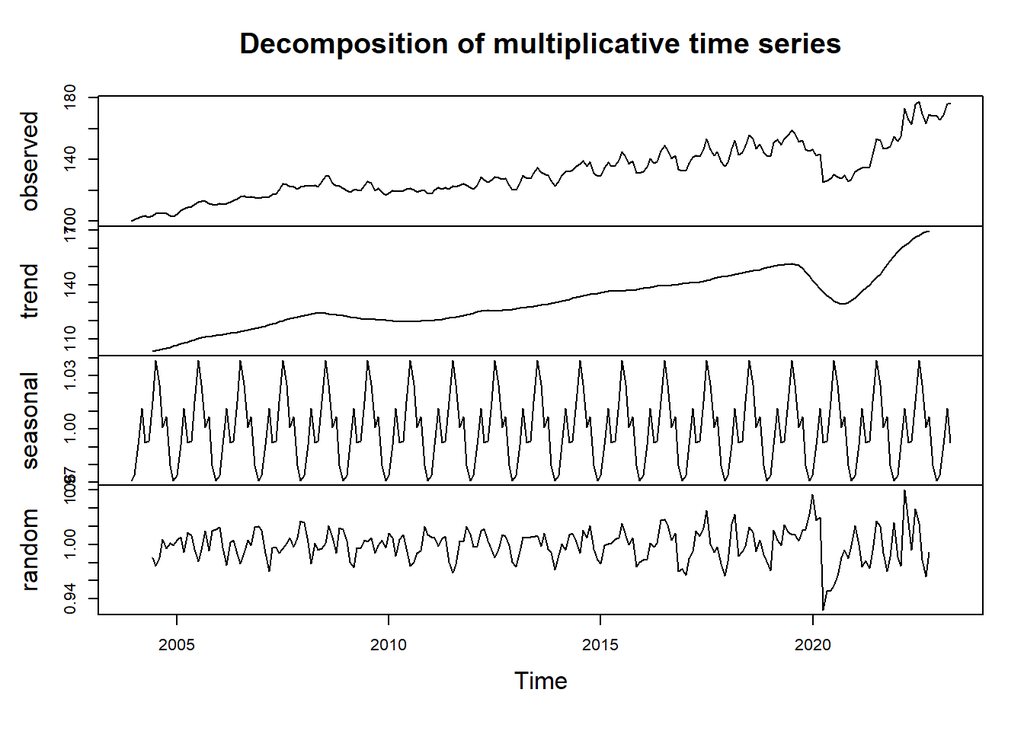

```r
plot(decompose(szereg1, type="multiplicative"))
```

Brak widocznej różnicy pomiędzy dekompozycją addytywną i multiplikatywną

### Dekompozycja za pomocą ruchomej średniej

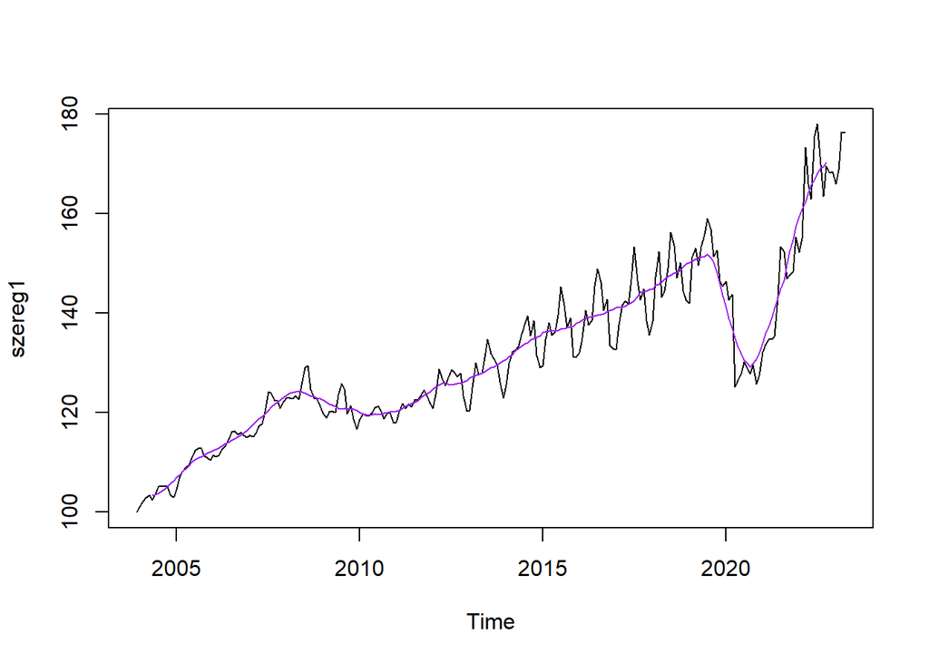

```r
ruchomesrednie1 <- filter(szereg1, sides = 2, filter = rep(1/12,12))
plot(szereg1)
lines(ruchomesrednie1, col = "purple")
```

### Dekompozycja na podstawie modelu regresji

#### Trend liniowy

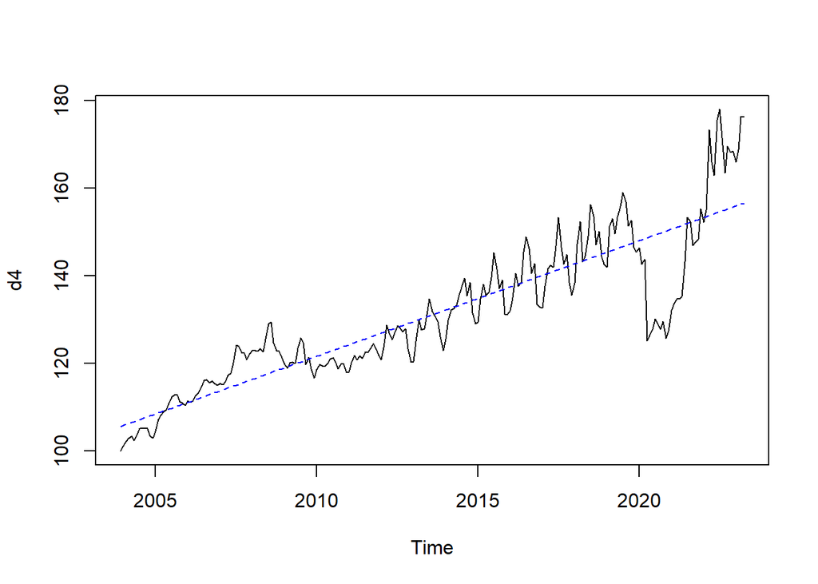

```r
d4 <- szereg1
elec_model <- tslm(d4 ~ trend)
plot(d4)
lines(fitted(elec_model), col = "blue", lty = 2)
```

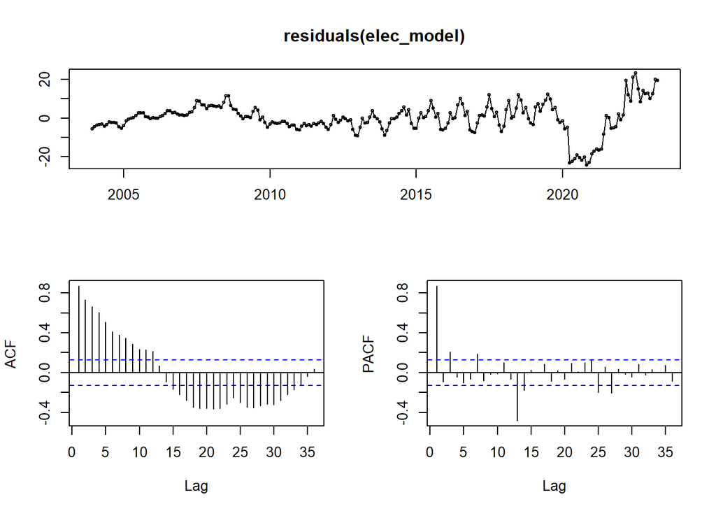

```r
tsdisplay(residuals(elec_model))
```

#### Trend liniowy i sezonowość

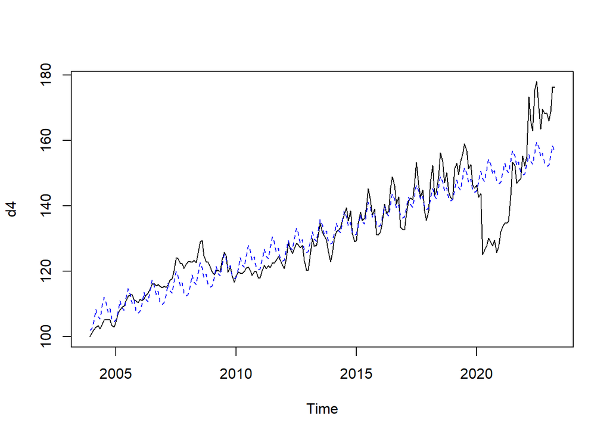

```r
elec_model_sezon <- tslm(d4 ~ trend +season)
plot(d4)
lines(fitted(elec_model_sezon), col="blue", lty=2)
```

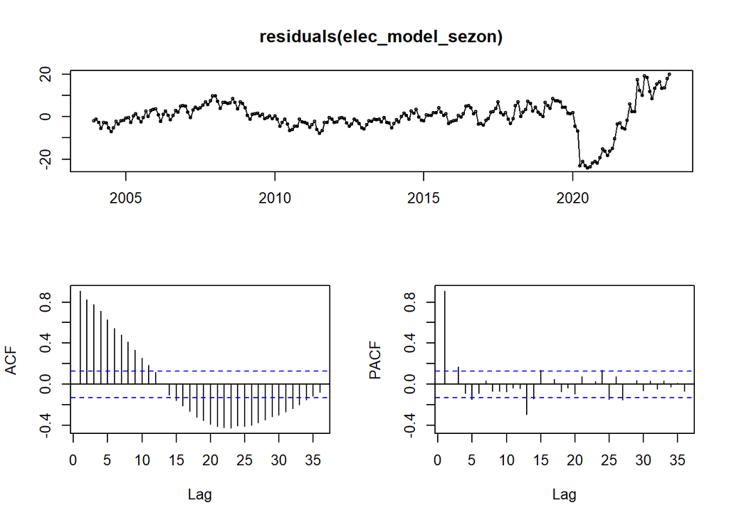

```r
tsdisplay(residuals(elec_model_sezon))
```

#### Trend liniowy, sezonowość i Box-Cox

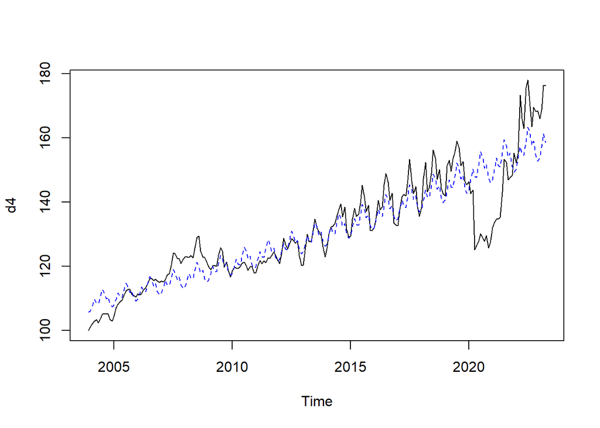

```r
elec_model_boxcox <- tslm(d4 ~ trend + season, lambda="auto")
plot(d4)
lines(fitted(elec_model_boxcox), col="blue", lty=2)
```

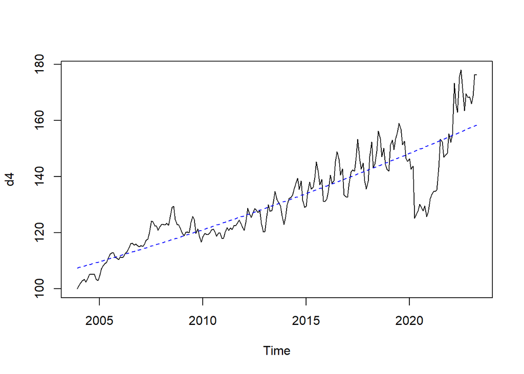

```r
bc <- tslm(d4 ~ poly(trend, raw=TRUE, degree = 2))
plot(d4)
lines(fitted(bc), col = "blue", lty = 2)
```

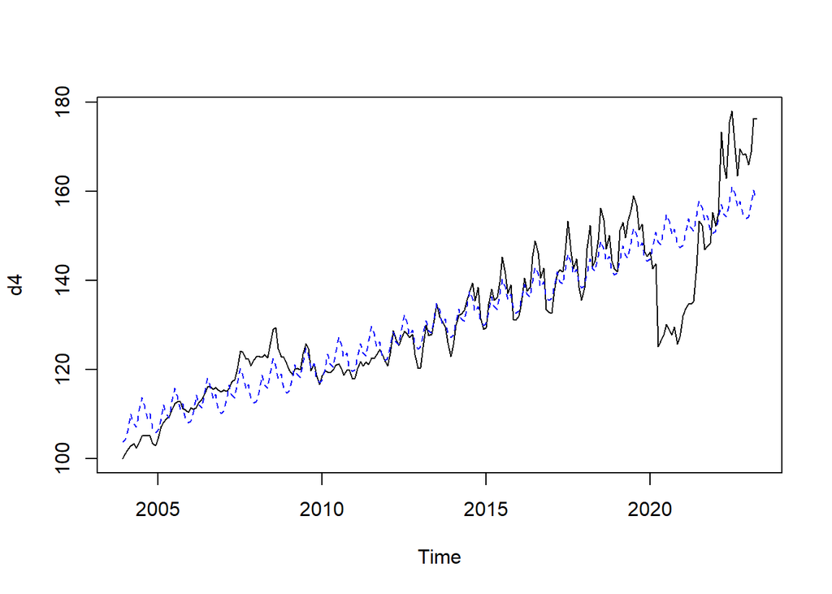

```r
bc_season <- tslm(d4 ~ poly(trend, raw=TRUE, degree = 2)+ season)
plot(d4)
lines(fitted(bc_season), col = "blue", lty = 2)
```

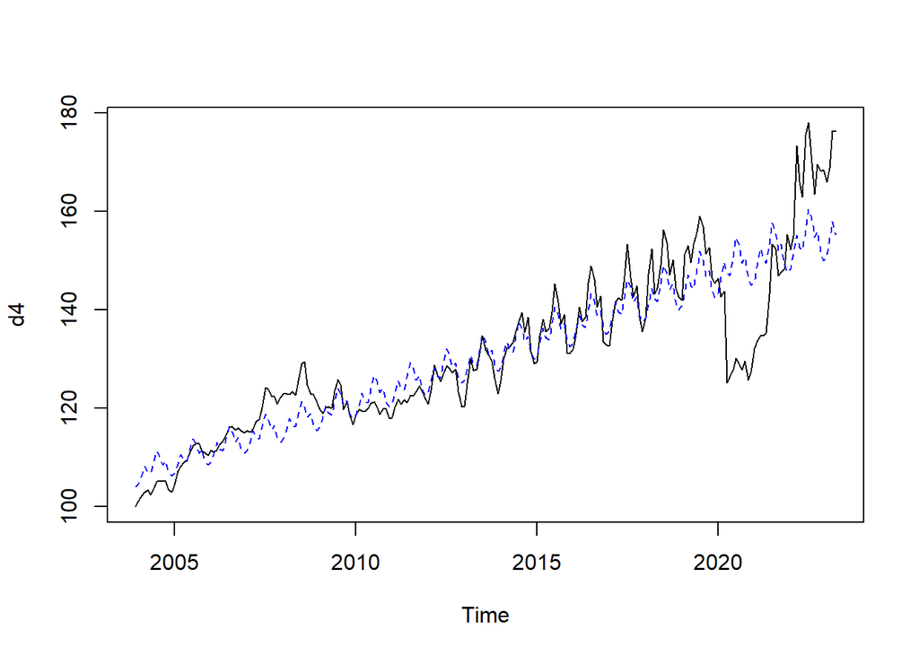

```r
bc_season_boxcox <- tslm(d4 ~ poly(trend, raw=TRUE, degree = 2)+ season, lambda="auto")
plot(d4)
lines(fitted(bc_season_boxcox), col = "blue", lty = 2)
```

#### Dla wielomianu st 5

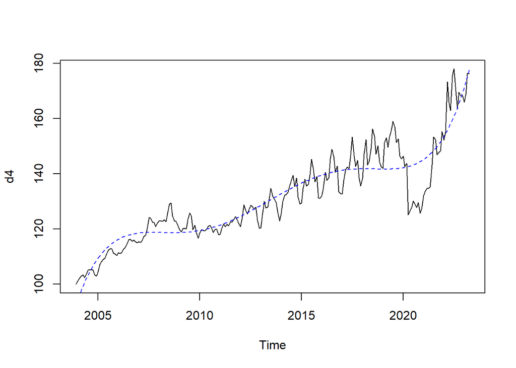

```r
bc <- tslm(d4 ~ poly(trend, raw=TRUE, degree = 5))
plot(d4)
lines(fitted(bc), col = "blue", lty = 2)
```

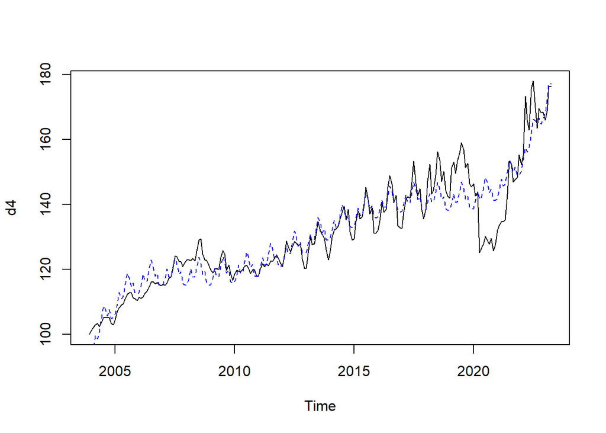

```r
bc_season <- tslm(d4 ~ poly(trend, raw=TRUE, degree = 5)+ season)
plot(d4)
lines(fitted(bc_season), col = "blue", lty = 2)
```

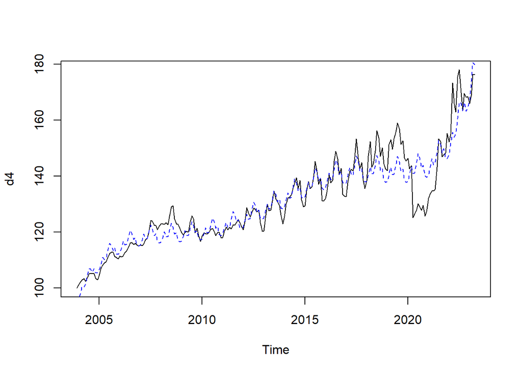

```r
bc_season_boxcox <- tslm(d4 ~ poly(trend, raw=TRUE, degree = 5)+ season, lambda="auto")
plot(d4)
lines(fitted(bc_season_boxcox), col = "blue", lty = 2)
```

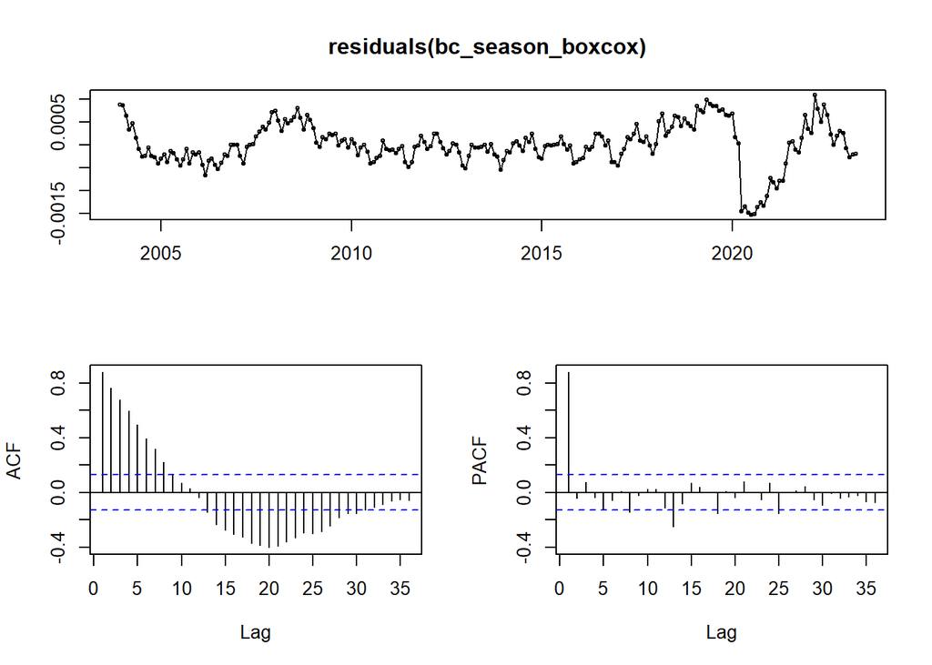

```r
tsdisplay(residuals(bc_season_boxcox))
```

## Szereg z wyraźnym trendem

### Dekompozycja addytywna

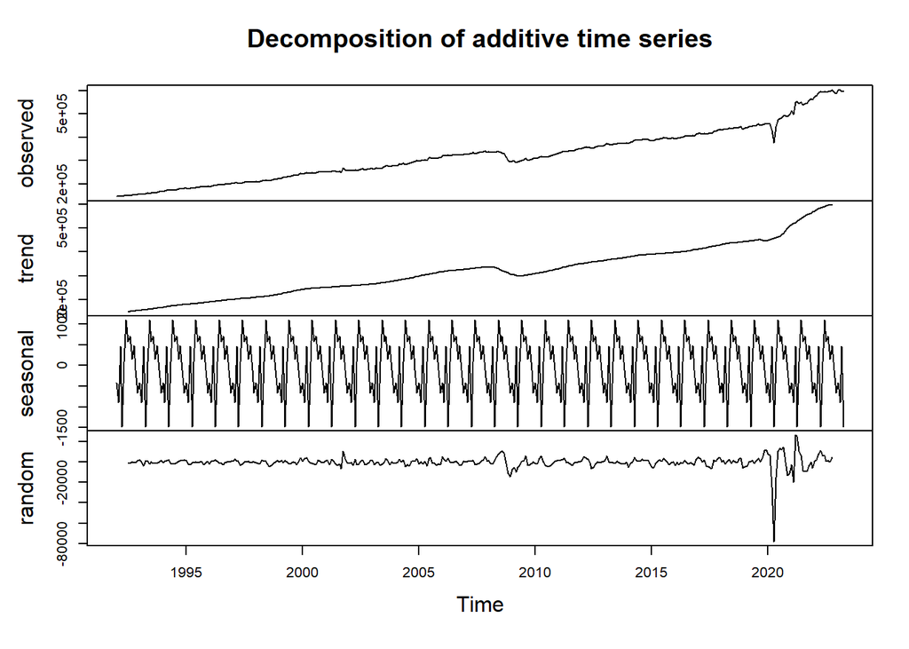

```r
plot(decompose(szereg2, type="additive"))
```

### Dekompozycja multiplikatywna

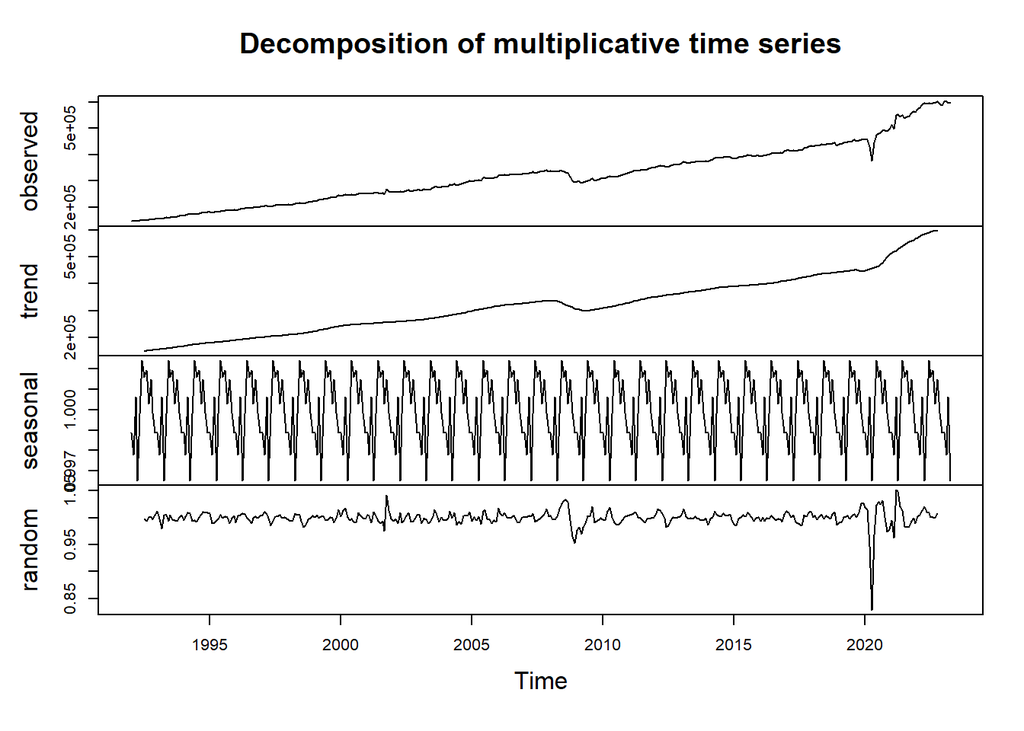

```r
plot(decompose(szereg2, type="multiplicative"))
```

Brak widocznej różnicy pomiędzy dekompozycją addytywną i multiplikatywną